# Mid Term - Animal Rights Index

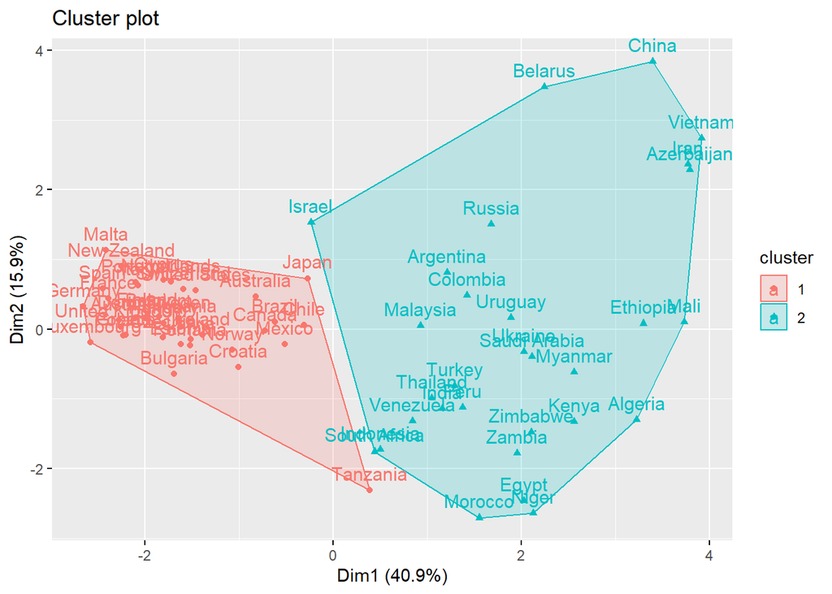

```r
#Visualizing the clusters


pam.res <- pam(matstd_animal, 2)
# Visualize
fviz_cluster(pam.res)
```

#Principal Component Analysis

```r
#Lets plot correlation between columns
animal_pca <- cor(animal) #correlation
animal_pca
```

```
##                                                         Recognition.of.Animal.Sentience
## Recognition.of.Animal.Sentience                                              1.00000000
## Recognition.of.Animal.Suffering                                              0.38935043
## Any.Laws.Against.Animal.Cruelty                                              0.09043831
## Support.for.the.Universal.Declaration.of.Animal.Welfare                      0.43070133
## Fur.Farming.Ban                                                              0.28488017
## Meat.Consumption.per.Capita.in.Kilograms                                     0.39829847
## Percentage.of.Protected.Areas                                                0.12213443
## Kgs.of.Pesticide...Hectare.of.Cropland                                      -0.06261079
## Environmental.Performance.Index.Score                                        0.47455942
## Total.Score                                                                  0.57789439
##                                                         Recognition.of.Animal.Suffering
## Recognition.of.Animal.Sentience                                              0.38935043
## Recognition.of.Animal.Suffering                                              1.00000000
## Any.Laws.Against.Animal.Cruelty                                              0.41983987
## Support.for.the.Universal.Declaration.of.Animal.Welfare                      0.27841294
## Fur.Farming.Ban                                                              0.09437972
## Meat.Consumption.per.Capita.in.Kilograms                                     0.10814868
## Percentage.of.Protected.Areas                                                0.23691549
## Kgs.of.Pesticide...Hectare.of.Cropland                                       0.08698954
## Environmental.Performance.Index.Score                                        0.22598771
## Total.Score                                                                  0.57300070
##                                                         Any.Laws.Against.Animal.Cruelty
## Recognition.of.Animal.Sentience                                             0.090438310
## Recognition.of.Animal.Suffering                                             0.419839872
## Any.Laws.Against.Animal.Cruelty                                             1.000000000
## Support.for.the.Universal.Declaration.of.Animal.Welfare                     0.090460664
## Fur.Farming.Ban                                                            -0.009885566
## Meat.Consumption.per.Capita.in.Kilograms                                   -0.109790706
## Percentage.of.Protected.Areas                                               0.156934813
## Kgs.of.Pesticide...Hectare.of.Cropland                                     -0.066465579
## Environmental.Performance.Index.Score                                       0.070490495
## Total.Score                                                                 0.328006718
##                                                         Support.for.the.Universal.Declaration.of.Animal.Welfare
## Recognition.of.Animal.Sentience                                                                      0.43070133
## Recognition.of.Animal.Suffering                                                                      0.27841294
## Any.Laws.Against.Animal.Cruelty                                                                      0.09046066
## Support.for.the.Universal.Declaration.of.Animal.Welfare                                              1.00000000
## Fur.Farming.Ban                                                                                      0.62683139
## Meat.Consumption.per.Capita.in.Kilograms                                                             0.31457623
```

[output cut: 55 more lines]

```
## Percentage.of.Protected.Areas                                                       0.2981991
## Kgs.of.Pesticide...Hectare.of.Cropland                                              0.3084785
## Environmental.Performance.Index.Score                                               1.0000000
## Total.Score                                                                         0.7204765
##                                                         Total.Score
## Recognition.of.Animal.Sentience                          0.57789439
## Recognition.of.Animal.Suffering                          0.57300070
## Any.Laws.Against.Animal.Cruelty                          0.32800672
## Support.for.the.Universal.Declaration.of.Animal.Welfare  0.74493792
## Fur.Farming.Ban                                          0.61986500
## Meat.Consumption.per.Capita.in.Kilograms                 0.39054193
## Percentage.of.Protected.Areas                            0.49751818
## Kgs.of.Pesticide...Hectare.of.Cropland                   0.09828063
## Environmental.Performance.Index.Score                    0.72047649
## Total.Score                                              1.00000000
```

```r
animal_pca2 <- prcomp(animal_pca,scale=TRUE)
animal_pca2
```

```
## Standard deviations (1, .., p=10):
##  [1] 2.019697e+00 1.686413e+00 1.118207e+00 8.119267e-01 7.166644e-01
##  [6] 5.987454e-01 4.064749e-01 3.262222e-01 1.532142e-01 3.955645e-17
##
## Rotation (n x k) = (10 x 10):
##                                                                 PC1
## Recognition.of.Animal.Sentience                         -0.28697712
## Recognition.of.Animal.Suffering                          0.13394678
## Any.Laws.Against.Animal.Cruelty                          0.30148895
## Support.for.the.Universal.Declaration.of.Animal.Welfare -0.41004821
## Fur.Farming.Ban                                         -0.43310165
## Meat.Consumption.per.Capita.in.Kilograms                -0.33641179
## Percentage.of.Protected.Areas                           -0.03348980
## Kgs.of.Pesticide...Hectare.of.Cropland                   0.06632401
## Environmental.Performance.Index.Score                   -0.45551890
## Total.Score                                             -0.35622946
##                                                                   PC2
## Recognition.of.Animal.Sentience                         -0.2504518754
## Recognition.of.Animal.Suffering                         -0.4398605070
## Any.Laws.Against.Animal.Cruelty                         -0.3771029231
## Support.for.the.Universal.Declaration.of.Animal.Welfare -0.2022309192
## Fur.Farming.Ban                                         -0.0008445363
## Meat.Consumption.per.Capita.in.Kilograms                 0.3278247561
## Percentage.of.Protected.Areas                           -0.1756242198
## Kgs.of.Pesticide...Hectare.of.Cropland                   0.5130628259
## Environmental.Performance.Index.Score                    0.1076177994
## Total.Score                                             -0.3841405063
##                                                                 PC3         PC4
## Recognition.of.Animal.Sentience                          0.49624425  0.30911438
## Recognition.of.Animal.Suffering                          0.28255378  0.32789306
## Any.Laws.Against.Animal.Cruelty                          0.04302463 -0.33983755
## Support.for.the.Universal.Declaration.of.Animal.Welfare -0.14576182 -0.26969036
## Fur.Farming.Ban                                         -0.19740368 -0.43127021
## Meat.Consumption.per.Capita.in.Kilograms                 0.23801238  0.28258581
## Percentage.of.Protected.Areas                           -0.73901398  0.56883982
## Kgs.of.Pesticide...Hectare.of.Cropland                  -0.01548727  0.11630799
## Environmental.Performance.Index.Score                    0.05409983  0.05565246
## Total.Score                                             -0.07668739  0.05157300
##                                                                 PC5         PC6
## Recognition.of.Animal.Sentience                         -0.33821595 -0.28823122
```

[output cut: 16 more lines]

```
## Percentage.of.Protected.Areas                           -0.04280931  0.03797846
## Kgs.of.Pesticide...Hectare.of.Cropland                  -0.35367609  0.24426220
## Environmental.Performance.Index.Score                   -0.19425862  0.24112168
## Total.Score                                             -0.13345558  0.13928912
##                                                                 PC9        PC10
## Recognition.of.Animal.Sentience                          0.16563605 -0.30653118
## Recognition.of.Animal.Suffering                         -0.16155434 -0.21153390
## Any.Laws.Against.Animal.Cruelty                          0.24305343 -0.36798543
## Support.for.the.Universal.Declaration.of.Animal.Welfare -0.10373316 -0.23580599
## Fur.Farming.Ban                                          0.21647113 -0.34574469
## Meat.Consumption.per.Capita.in.Kilograms                 0.36270544 -0.09928319
## Percentage.of.Protected.Areas                            0.04566491 -0.26438293
## Kgs.of.Pesticide...Hectare.of.Cropland                   0.31181767 -0.23619557
## Environmental.Performance.Index.Score                   -0.65346799 -0.01700239
## Total.Score                                              0.41458221  0.64412887
```

```r
summary(animal_pca2)
```

```
## Importance of components:
##                           PC1    PC2    PC3     PC4     PC5     PC6     PC7
## Standard deviation     2.0197 1.6864 1.1182 0.81193 0.71666 0.59875 0.40647
## Proportion of Variance 0.4079 0.2844 0.1250 0.06592 0.05136 0.03585 0.01652
## Cumulative Proportion  0.4079 0.6923 0.8174 0.88328 0.93464 0.97049 0.98701
##                            PC8     PC9      PC10
## Standard deviation     0.32622 0.15321 3.956e-17
## Proportion of Variance 0.01064 0.00235 0.000e+00
## Cumulative Proportion  0.99765 1.00000 1.000e+00
```

# Scree Plots

```r
(eigen_animal <- animal_pca2$sdev^2)
```

```
##  [1] 4.079177e+00 2.843990e+00 1.250387e+00 6.592250e-01 5.136079e-01
##  [6] 3.584960e-01 1.652219e-01 1.064209e-01 2.347459e-02 1.564713e-33
```

```r
names(eigen_animal) <- paste("PC",1:9,sep="")
```

Higher eigenvalues indicate better explanatory power. These eigenvalues show how much variance is explained by each primary component

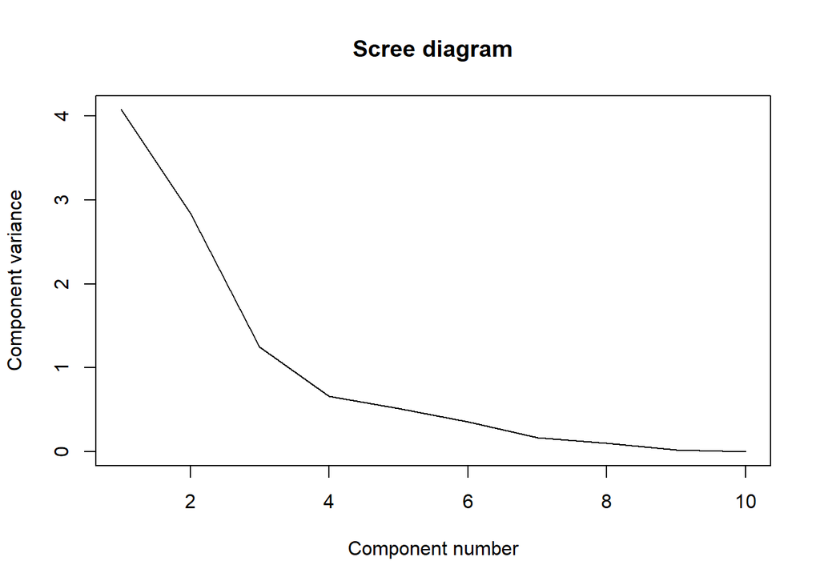

```r
plot(eigen_animal, xlab = "Component number", ylab = "Component variance", type = "l", main = "Scree diagram")
```

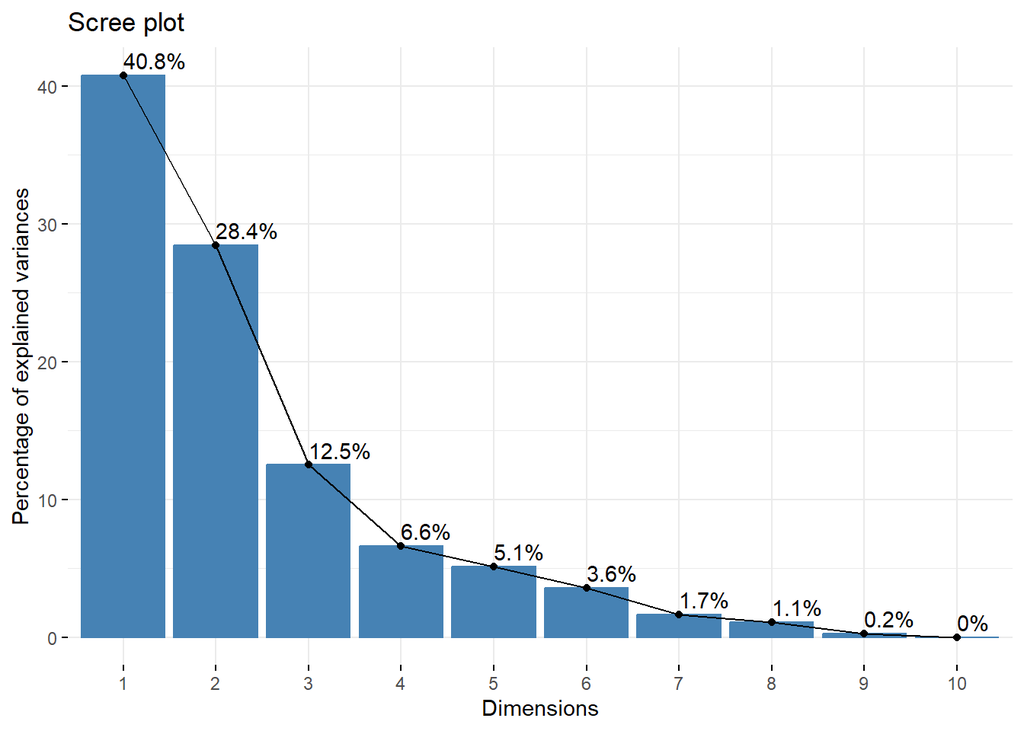

```r
fviz_eig(animal_pca2, addlabels = TRUE)
```

### Biplot

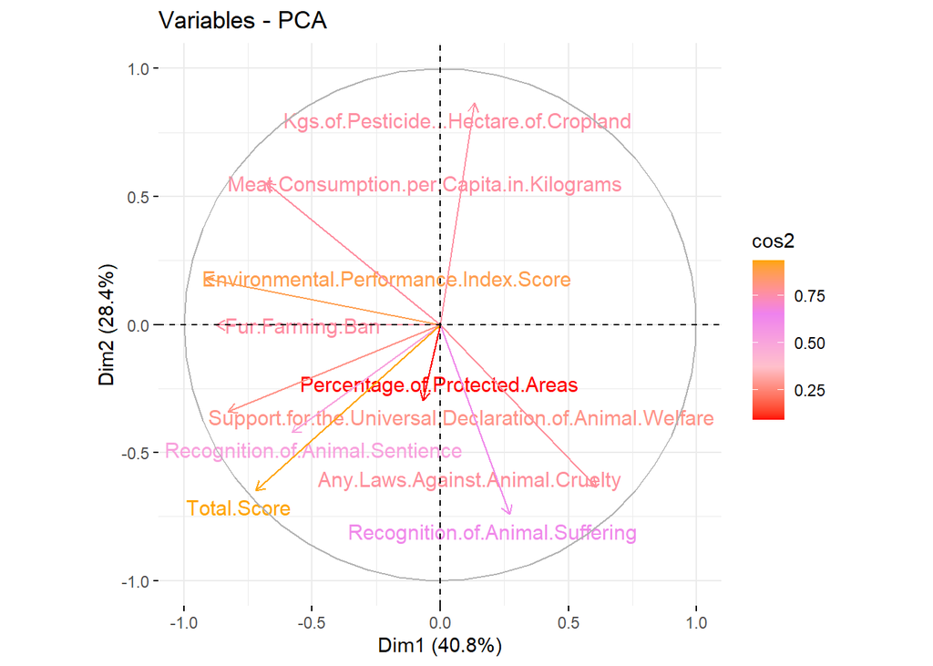

```r
fviz_pca_var(animal_pca2,col.var = "cos2",
             gradient.cols = c("red", "pink", "violet", "orange"),
             repel = TRUE)
```

1. The distance between points in a biplot indicates the general similarity or dissimilarity of the observations.
2. Variables with longer vectors are more variable or have a greater explanatory power over the data.
3. How related or unrelated the variables are is reflected in the angle between the vectors. A higher correlation between the variables is shown by a smaller angle.
4. Biplots also aid in the visualization of data patterns and linkages, which facilitates the understanding of complicated datasets.

### Individual PCA

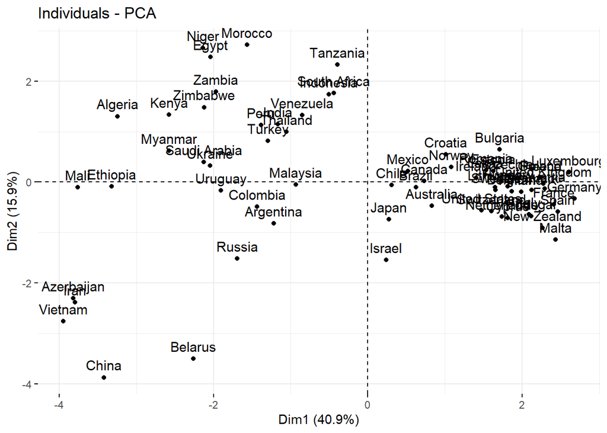

```r
res.pca <- PCA(animal1, graph = FALSE)

fviz_pca_ind(res.pca)
```

In the individual PCA plot, the countries have been plotted according to their PCA values.

### PCA - Biplot

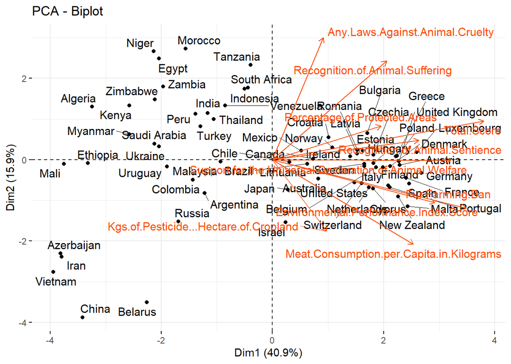

```r
fviz_pca_biplot(res.pca, repel = TRUE,
                col.var = "#FC4E07", # Variables color
                )
```

# The biplot helps to identify the outliers, in this case we could see many outliers such as China, Belarus, Vietnam, Iran,Azerbaijan etc..The highlighted part in orange gives the variables most of the countries, lies in the part of the variables.

# Thus, the PCA helped us and tell us their similarities. In our further analysis, we can see if this still stands and find the underlying reason behind this observation.